# What Ratio Will Predict Home Runs: 2019 Data

Andrew Picciano

January 18, 2020

## Background

I am trying to predict the number of home runs (HR’s) based on a series of predictors from 2019 hitting statistics. The statistics include: Games, At-Bats, Runs, Hits, Doubles (2B), Triples (3B), RBI, BB (Walks), SO (Strikeouts), SB (Stolen Bases), CS (Caught Stealing), BA (Batting Average).

```r
rm(list=ls()) # clear environment
# Load libraries function
installIfAbsentAndLoad <- function(neededVector) {
  for(thispackage in neededVector) {
    if( ! require(thispackage, character.only = T) )
    { install.packages(thispackage)}
    library(thispackage, character.only = T)
  }
}
par(mfrow =c(1,1))
needed <- c('tree', "ISLR")
```

```r
data <- read.csv('2019MLBstats.csv', header = TRUE, sep = ',')
# To take out impact of players that only played part of season, make ratios of BB, SO, Hits on a per game or per at bat level
BB_Ratio <- data$BB / data$AB # Create BB_Ratio: Walk Ratio
SO_Ratio <- data$SO / data$AB # Create SO_Ratio: Strikeout Ratio
Hits_Game <- data$H / data$G  # Create Hits_Game:
data2 <- data.frame(data, BB_Ratio, SO_Ratio, Hits_Game) #create dataframe with new calculations
y_HR <- data2[10]
trainIndex <- sample(nrow(data2), nrow(data2) * .8)  # assign 80% of rows to get train rows
Xtrain <- data2[trainIndex, -10] # make the train row X's. DO NOT pull in the HR column since trying to predict it
Xtest <- data2[-trainIndex, -10] # make test row X's. There are 70 rows since taking 20% of rows
Ytrain <- data2[trainIndex, 10]
Ytest <- data2[-trainIndex, 10]
```

## Exploratory Analysis

Do some exploratory analysis to see relationship between HR and ratios I created. The purpose is to find linearity. If not linear, I will use some higher level polynomial terms. Also, if no relationship, I will remove it from the analysis.

##### Strikeout Ratio

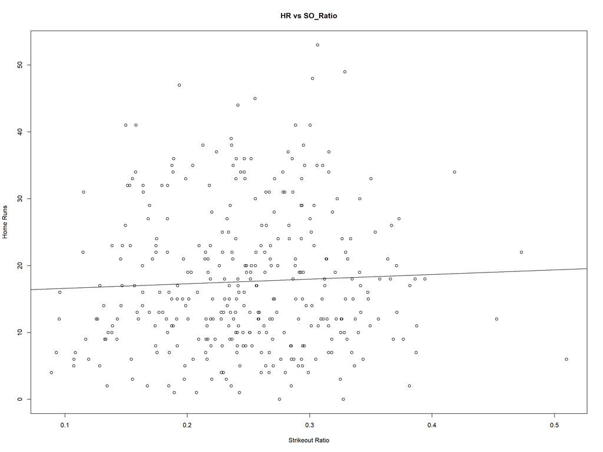

```r
plot(data2$SO_Ratio, data2$HR, main = 'HR vs SO_Ratio', xlab = 'Strikeout Ratio', ylab = 'Home Runs')
lm.fit2 <- lm(data2$HR ~ data2$SO_Ratio , data = data2)
abline(lm.fit2)
```

```r
summary(lm.fit2)
```

```
##
## Call:
## lm(formula = data2$HR ~ data2$SO_Ratio, data = data2)
##
## Residuals:
##     Min      1Q  Median      3Q     Max
## -18.176  -7.742  -2.312   6.061  34.968
##
## Coefficients:
##                Estimate Std. Error t value Pr(>|t|)
## (Intercept)      15.930      2.090   7.623 2.43e-13 ***
## data2$SO_Ratio    6.860      8.088   0.848    0.397
## ---
## Signif. codes:  0 '***' 0.001 '**' 0.01 '*' 0.05 '.' 0.1 ' ' 1
##
## Residual standard error: 10.52 on 344 degrees of freedom
## Multiple R-squared:  0.002087,   Adjusted R-squared:  -0.0008141
## F-statistic: 0.7194 on 1 and 344 DF,  p-value: 0.3969
```

Data indicates very minimal linearity or relationship. Players who hit the same number of HR seem to be on the same level of Strikeout ratio. I added abline. Since abline slope is relatively flat, there isn’t much, if at all a relationship. Surprising, I was expecting to see a negative correlation between HR and SO_Ratio; better HR hitters would have a lower *SO_Ratio*. Running summary on the linear model shows a high p-value, indicating a lack of statistical significance since cannot reject the *Null hypothesis.*

##### Walk Ratio

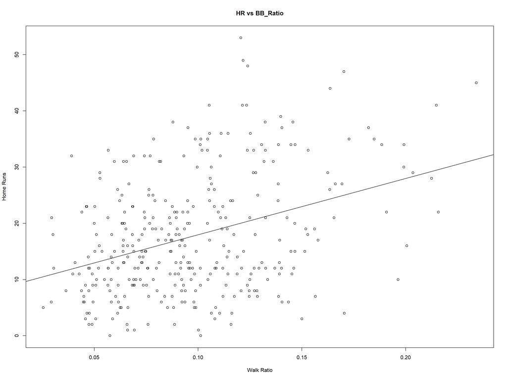

```r
plot(data2$BB_Ratio, data2$HR, main = 'HR vs BB_Ratio', xlab = 'Walk Ratio', ylab = 'Home Runs')
lm.fit5 <- lm(data2$HR ~ data2$BB_Ratio, data = data2)
abline(lm.fit5)
```

Data indicates there is a better relationship between players having a ‘better eye’ and hitting more HR. slope of abline is higher than the SO_Ration so more of a relationship.

##### Hits per Game Ratio

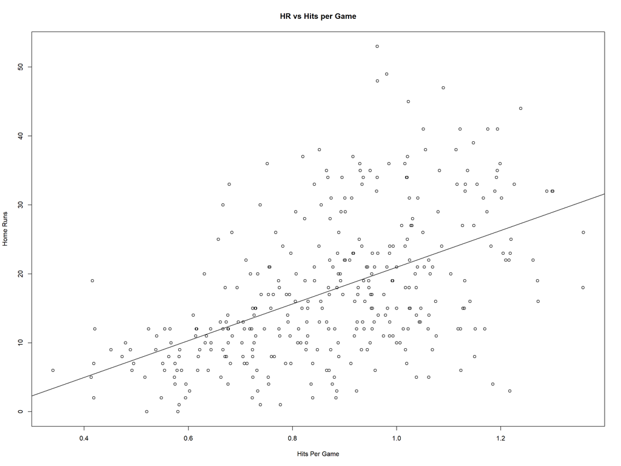

```r
plot(data2$Hits_Game, data2$HR, main = 'HR vs Hits per Game', xlab = 'Hits Per Game', ylab = 'Home Runs')
lm.fit3 <- lm(data2$HR ~ data2$Hits_Game , data = data2)
abline(lm.fit3)
```

Data indicates there is a direct linear relationship between players having more hits and hitting more HR. This isnt surprising seeing players who hit got on base with a hit in one At Bat, can also hit a HR in same game. I will use this information later on.

## Fit Linear Regression Models:

[output not shown]

```r
lm.fit2 <- lm(data2$HR ~ data2$SO_Ratio , data = data2)
# summary(lm.fit2)

lm.fit3 <- lm(data2$HR ~ data2$Hits_Game , data = data2)
summary(lm.fit3)
```

```
##
## Call:
## lm(formula = data2$HR ~ data2$Hits_Game, data = data2)
##
## Residuals:
##     Min      1Q  Median      3Q     Max
## -23.754  -6.182  -1.100   4.268  33.031
##
## Coefficients:
##                 Estimate Std. Error t value Pr(>|t|)
## (Intercept)       -5.682      2.182  -2.604  0.00961 **
## data2$Hits_Game   26.644      2.430  10.964  < 2e-16 ***
## ---
## Signif. codes:  0 '***' 0.001 '**' 0.01 '*' 0.05 '.' 0.1 ' ' 1
##
## Residual standard error: 9.067 on 344 degrees of freedom
## Multiple R-squared:  0.259,  Adjusted R-squared:  0.2568
## F-statistic: 120.2 on 1 and 344 DF,  p-value: < 2.2e-16
```

```r
lm.fit4 <- lm(data2$HR ~ data2$BB_Ratio + data2$Hits_Game , data = data2)
summary(lm.fit4)
```

```
##
## Call:
## lm(formula = data2$HR ~ data2$BB_Ratio + data2$Hits_Game, data = data2)
##
## Residuals:
##      Min       1Q   Median       3Q      Max
## -23.9549  -5.1267  -0.4292   4.9458  30.2006
##
## Coefficients:
##                 Estimate Std. Error t value Pr(>|t|)
## (Intercept)      -17.998      2.292  -7.851 5.32e-14 ***
## data2$BB_Ratio   111.981     11.296   9.913  < 2e-16 ***
## data2$Hits_Game   28.348      2.153  13.170  < 2e-16 ***
## ---
## Signif. codes:  0 '***' 0.001 '**' 0.01 '*' 0.05 '.' 0.1 ' ' 1
##
## Residual standard error: 8.006 on 343 degrees of freedom
## Multiple R-squared:  0.424,  Adjusted R-squared:  0.4206
## F-statistic: 126.2 on 2 and 343 DF,  p-value: < 2.2e-16
```

```r
lm.fit5 <- lm(data2$HR ~ data2$BB_Ratio, data = data2)
summary(lm.fit5)
```

```
##
## Call:
## lm(formula = data2$HR ~ data2$BB_Ratio, data = data2)
##
## Residuals:
##     Min      1Q  Median      3Q     Max
## -21.019  -7.446  -1.234   6.229  32.968
##
## Coefficients:
##                Estimate Std. Error t value Pr(>|t|)
## (Intercept)       7.960      1.434   5.551 5.70e-08 ***
## data2$BB_Ratio  100.100     13.797   7.255 2.68e-12 ***
## ---
## Signif. codes:  0 '***' 0.001 '**' 0.01 '*' 0.05 '.' 0.1 ' ' 1
##
## Residual standard error: 9.809 on 344 degrees of freedom
## Multiple R-squared:  0.1327, Adjusted R-squared:  0.1302
## F-statistic: 52.64 on 1 and 344 DF,  p-value: 2.68e-12
```

```r
anova(lm.fit3, lm.fit5, lm.fit4)
```

```
## Analysis of Variance Table
##
## Model 1: data2$HR ~ data2$Hits_Game
## Model 2: data2$HR ~ data2$BB_Ratio
## Model 3: data2$HR ~ data2$BB_Ratio + data2$Hits_Game
##   Res.Df   RSS Df Sum of Sq      F    Pr(>F)
## 1    344 28283
## 2    344 33101  0   -4818.5
## 3    343 21984  1   11116.8 173.45 < 2.2e-16 ***
## ---
## Signif. codes:  0 '***' 0.001 '**' 0.01 '*' 0.05 '.' 0.1 ' ' 1
```

After running an ANOVA (Analsis of Variance), I see that I should use **BOTH** BB_Ratio and Hits_Game seem to provide lowest Residual Sum of Squares (a Cost Function we are trying to minimize). In addition, the p-value is below the alpha of 0.05, so this model is significant.

I want to doublecheck multicollinearity, I want to do a Variance Inflation Factor - which measures collinearity. If a value is above 5 or 10, indicates multicollinearity and I can choose simpler model. Good news, only 1 so unimportant.

```r
library(car)
vif(lm.fit4)
```

```
##  data2$BB_Ratio data2$Hits_Game
##        1.006419        1.006419
```